Following the example we walked through in class, and another example on Github (Links to an external site.)Links to an external site., create a jupyter notebook that completes the following steps. Upload the notebook to your github repo and submit the link for credit or post your notebook file.

Use the following data set to answer the questions for your homework

import pandas as pd import matplotlib.pyplot as plt

# run plots in the notebook

Subset the dataframe to contain only the name, category, quantity and unit price columns

Subset the dataframe to contain only shirt sales

Calculate the total cost per shirt sale

Group the shirt sales by company name Pull out top 10 shirt sales Graph the top 10 shirt sales Save the notebook as either a PDF or HTML page Upload it to your github repo Post a link to your jupyternote book for credit

```python
import pandas as pd
import matplotlib.pyplot as plt

# run plots in the notebook
%matplotlib inline
url = "http://pbpython.com/extras/sample-salesv2.csv"
sales = pd.read_csv(url)

sales.head()
```

|  | account number | name | sku | category | quantity | unit price | ext price | date |
| --- | --- | --- | --- | --- | --- | --- | --- | --- |
| 0 | 296809 | Carroll PLC | QN-82852 | Belt | 13 | 44.48 | 578.24 | 2014-09-27 07:13:03 |
| 1 | 98022 | Heidenreich-Bosco | MJ-21460 | Shoes | 19 | 53.62 | 1018.78 | 2014-07-29 02:10:44 |
| 2 | 563905 | Kerluke, Reilly and Bechtelar | AS-93055 | Shirt | 12 | 24.16 | 289.92 | 2014-03-01 10:51:24 |
| 3 | 93356 | Waters-Walker | AS-93055 | Shirt | 5 | 82.68 | 413.40 | 2013-11-17 20:41:11 |
| 4 | 659366 | Waelchi-Fahey | AS-93055 | Shirt | 18 | 99.64 | 1793.52 | 2014-01-03 08:14:27 |

```python
#change column names to use underscores

sales.columns = ['Account_Number', 'Name', 'SKU', 'Category', 'Quantity', 'Unit_Price', 'Ext_Price', 'Date']
sales.head()
```

|  | Account_Number | Name | SKU | Category | Quantity | Unit_Price | Ext_Price | Date |
| --- | --- | --- | --- | --- | --- | --- | --- | --- |
| 0 | 296809 | Carroll PLC | QN-82852 | Belt | 13 | 44.48 | 578.24 | 2014-09-27 07:13:03 |
| 1 | 98022 | Heidenreich-Bosco | MJ-21460 | Shoes | 19 | 53.62 | 1018.78 | 2014-07-29 02:10:44 |
| 2 | 563905 | Kerluke, Reilly and Bechtelar | AS-93055 | Shirt | 12 | 24.16 | 289.92 | 2014-03-01 10:51:24 |
| 3 | 93356 | Waters-Walker | AS-93055 | Shirt | 5 | 82.68 | 413.40 | 2013-11-17 20:41:11 |
| 4 | 659366 | Waelchi-Fahey | AS-93055 | Shirt | 18 | 99.64 | 1793.52 | 2014-01-03 08:14:27 |

```python
#Subset the dataframe to contain only the name, category, quantity and unit price columns
subset = sales[['Name', 'Category', 'Quantity', 'Unit_Price']].copy()
subset.head()
```

|  | Name | Category | Quantity | Unit_Price |
| --- | --- | --- | --- | --- |
| 0 | Carroll PLC | Belt | 13 | 44.48 |
| 1 | Heidenreich-Bosco | Shoes | 19 | 53.62 |
| 2 | Kerluke, Reilly and Bechtelar | Shirt | 12 | 24.16 |
| 3 | Waters-Walker | Shirt | 5 | 82.68 |
| 4 | Waelchi-Fahey | Shirt | 18 | 99.64 |

```python
#Subset the dataframe to contain only shirt sales
shirt_sales = subset[subset['Category'] == "Shirt"].copy()
shirt_sales.head()
```

|  | Name | Category | Quantity | Unit_Price |
| --- | --- | --- | --- | --- |
| 2 | Kerluke, Reilly and Bechtelar | Shirt | 12 | 24.16 |
| 3 | Waters-Walker | Shirt | 5 | 82.68 |
| 4 | Waelchi-Fahey | Shirt | 18 | 99.64 |
| 5 | Kerluke, Reilly and Bechtelar | Shirt | 17 | 52.82 |
| 9 | Kerluke, Reilly and Bechtelar | Shirt | 12 | 26.98 |

```python
#Calculate the total cost per shirt sale
#total cost per shirt sale = Quantity * Unit Price
shirt_sales['Total_Cost'] = shirt_sales['Quantity'] * shirt_sales['Unit_Price']
shirt_sales.head()
```

|  | Name | Category | Quantity | Unit_Price | Total_Cost |
| --- | --- | --- | --- | --- | --- |
| 2 | Kerluke, Reilly and Bechtelar | Shirt | 12 | 24.16 | 289.92 |
| 3 | Waters-Walker | Shirt | 5 | 82.68 | 413.40 |
| 4 | Waelchi-Fahey | Shirt | 18 | 99.64 | 1793.52 |
| 5 | Kerluke, Reilly and Bechtelar | Shirt | 17 | 52.82 | 897.94 |
| 9 | Kerluke, Reilly and Bechtelar | Shirt | 12 | 26.98 | 323.76 |

```python
#Group the shirt sales by company name
shirt_sales.groupby('Name')
```

```
<pandas.core.groupby.groupby.DataFrameGroupBy object at 0x000001FDA6690940>
```

```python
#Pull out top 10 shirt sales
max(shirt_sales['Total_Cost'])
```

```
1994.8
```

```python
#Pull out top 10 shirt sales
top10 = shirt_sales.sort_values(['Total_Cost'],ascending=[0]).head(10)
top10.head(10)
```

|  | Name | Category | Quantity | Unit_Price | Total_Cost |
| --- | --- | --- | --- | --- | --- |
| 986 | Waters-Walker | Shirt | 20 | 99.74 | 1994.80 |
| 182 | Hegmann and Sons | Shirt | 20 | 96.98 | 1939.60 |
| 918 | Cole-Eichmann | Shirt | 20 | 96.14 | 1922.80 |
| 214 | Kihn, McClure and Denesik | Shirt | 20 | 95.60 | 1912.00 |
| 383 | Heidenreich-Bosco | Shirt | 20 | 94.00 | 1880.00 |
| 4 | Waelchi-Fahey | Shirt | 18 | 99.64 | 1793.52 |
| 863 | Kilback-Gerlach | Shirt | 20 | 88.71 | 1774.20 |
| 950 | Hamill-Hackett | Shirt | 18 | 98.39 | 1771.02 |
| 949 | Cole-Eichmann | Shirt | 18 | 97.33 | 1751.94 |
| 486 | Volkman, Goyette and Lemke | Shirt | 19 | 89.14 | 1693.66 |

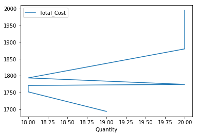

```python
#makeplotz
top10.plot(x = 'Quantity', y = 'Total_Cost')
```

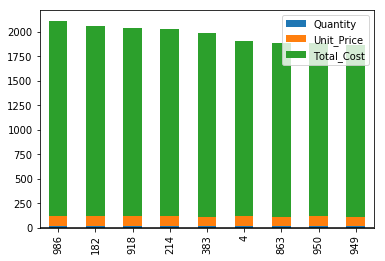

```python
#makeplotz
top10.iloc[:-1].plot.bar(stacked=True); plt.axhline(1, color='k')
```